# National and Subnational estimates for Italy

Subnational estimates Europe Italy

Identifying changes in the reproduction number, rate of spread, and doubling time during the course of the COVID-19 outbreak whilst accounting for potential biases due to delays in case reporting both nationally and subnationally in Italy. These results are impacted by changes in testing effort, increases and decreases in testing effort will increase and decrease reproduction number estimates respectively.

*Using data available up to the:* 2021-12-05

*Subnational and national estimates are available to download [here](https://dataverse.harvard.edu/dataverse/covid-rt).*

*See our see [Methods](https://epiforecasts.io/covid/methods) or our [paper](https://wellcomeopenresearch.org/articles/5-112/) for an explanation of how these estimates are derived.*

## National summary

### Summary (estimates as of the 2021-12-05)

*Table 1: Latest estimates (as of the 2021-12-05) of the number of confirmed cases by date of infection, the expected change in daily confirmed cases, the effective reproduction number, the growth rate, and the doubling time (when negative this corresponds to the halving time). The median and 90% credible interval is shown for each numeric estimate.*

|  | Estimate |
| --- | --- |
| New confirmed cases by infection date | 17661 (13261 – 23529) |
| Expected change in daily cases | Likely increasing |
| Effective reproduction no. | 1.1 (0.96 – 1.3) |
| Rate of growth | 0.031 (-0.011 – 0.078) |
| Doubling/halving time (days) | 22 (8.9 – -63) |

### Confirmed cases, their estimated date of report, date of infection, and time-varying reproduction number estimates

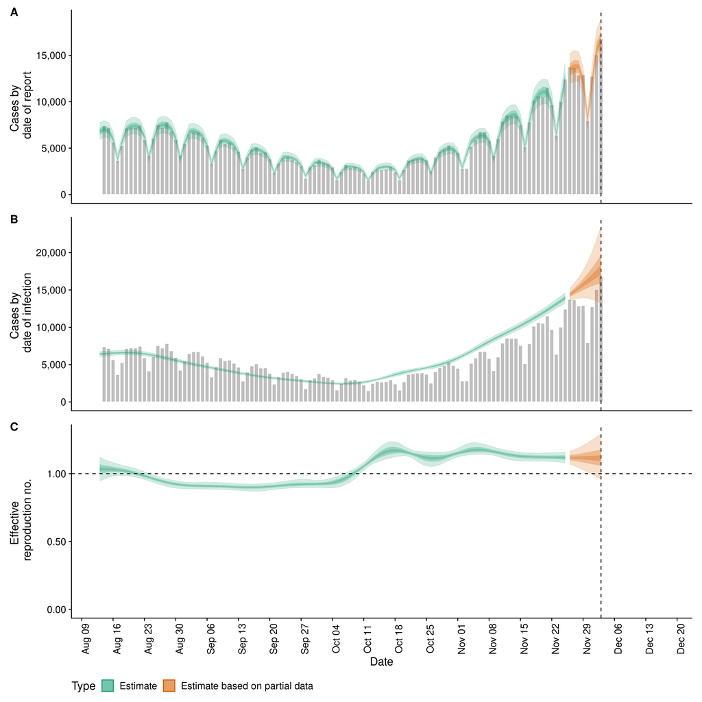

*Figure 1: A.) Confirmed cases by date of report (bars) and their estimated date of report. B.) Confirmed cases by date of report (bars) and their estimated date of infection. C.) Time-varying estimate of the effective reproduction number (lightest ribbon = 90% credible interval; darker ribbon = the 50% credible interval, darkest ribbon = 20% credible interval). Estimates from existing data are shown up to the 2021-12-05 from when forecasts are shown. These should be considered indicative only. Estimates based on partial data have been adjusted for right truncation of infections. The vertical dashed line indicates the date of report generation. Uncertainty has been curtailed to a maximum of ten times the maximum number of reported cases for plotting purposes.*

## Subnational breakdown

[interactive chart not shown]

*Figure 2: The results of the latest reproduction number estimates (based on confirmed cases in Italy, stratified by Region, can be summarised by whether confirmed cases are likely increasing or decreasing. This represents the strength of the evidence that the reproduction number in each region is greater than or less than 1, respectively (see the [methods](https://epiforecasts.io/covid/methods.html) for details).*

| Region | New confirmed cases by infection date | Expected change in daily cases | Effective reproduction no. | Rate of growth | Doubling/halving time (days) | New confirmed cases by infection date | Effective reproduction no. | Rate of growth | Doubling/halving time (days) |
| --- | --- | --- | --- | --- | --- | --- | --- | --- | --- |
| Abruzzo | 258 (151 -- 437) | Likely increasing | 1 (0.86 -- 1.3) | 0.012 (-0.04 -- 0.069) | 58 (10 -- -17) | 258 | 1 | 0.012 | 58 |
| Basilicata | 53 (32 -- 93) | Likely increasing | 1.1 (0.95 -- 1.4) | 0.033 (-0.013 -- 0.11) | 21 (6.5 -- -51) | 53 | 1.1 | 0.033 | 21 |
| Calabria | 433 (300 -- 661) | Increasing | 1.2 (1 -- 1.4) | 0.047 (0.0071 -- 0.098) | 15 (7 -- 98) | 433 | 1.2 | 0.047 | 15 |
| Campania | 1395 (994 -- 1940) | Likely increasing | 1.1 (0.94 -- 1.2) | 0.023 (-0.017 -- 0.065) | 30 (11 -- -41) | 1395 | 1.1 | 0.023 | 30 |
| Emilia-Romagna | 1811 (1345 -- 2377) | Likely increasing | 1.1 (0.96 -- 1.2) | 0.025 (-0.012 -- 0.061) | 28 (11 -- -57) | 1811 | 1.1 | 0.025 | 28 |
| Friuli Venezia Giulia | 678 (388 -- 1239) | Stable | 1 (0.82 -- 1.3) | 0.0077 (-0.051 -- 0.083) | 90 (8.4 -- -14) | 678 | 1 | 0.0077 | 90 |
| Lazio | 1873 (1338 -- 2603) | Likely increasing | 1.1 (0.93 -- 1.3) | 0.022 (-0.02 -- 0.07) | 32 (9.9 -- -34) | 1873 | 1.1 | 0.022 | 32 |
| Liguria | 598 (400 -- 862) | Likely increasing | 1.1 (0.95 -- 1.3) | 0.027 (-0.015 -- 0.07) | 25 (10 -- -46) | 598 | 1.1 | 0.027 | 25 |
| Lombardia | 3130 (2294 -- 4367) | Likely increasing | 1.1 (0.96 -- 1.3) | 0.025 (-0.01 -- 0.067) | 28 (10 -- -67) | 3130 | 1.1 | 0.025 | 28 |
| Marche | 506 (324 -- 752) | Likely increasing | 1.1 (0.89 -- 1.2) | 0.015 (-0.031 -- 0.057) | 45 (12 -- -23) | 506 | 1.1 | 0.015 | 45 |

[output cut: 10 more lines]

*Table 2: Latest estimates (as of the 2021-12-05) of the number of confirmed cases by date of infection, the effective reproduction number, the rate of growth, and the doubling time (when negative this corresponds to the halving time) in each region. The median and 90% credible interval is shown.*

## Data availability

- Case counts by date, stratified by region, were constructed from daily data-sets made publicly available by the Dipartimento della Protezione Civile (Dipartimento della Protezione Civile, n.d.; Abbott et al. 2020).
- Case onset dates were estimated using case counts by date of report and a distribution of reporting delays fitted to an international line-list (Xu et al., n.d.; Abbott et al. 2020).

## Limitations

- Line-list data to inform a Italy specific estimate of the reporting delay was not available. This means that we could also not account for any regional differences.

Abbott, Sam, Katharine Sherratt, Jonnie Bevan, Hamish Gibbs, Joel Hellewell, James Munday, Patrick Barks, Paul Campbell, Flavio Finger, and Sebastian Funk. 2020. “Covidregionaldata: Subnational Data for the Covid-19 Outbreak.” *-* - (-): –. https://doi.org/10.5281/zenodo.3957539.

Dipartimento della Protezione Civile. n.d. “Dati COVID-19 Italia.” https://github.com/pcm-dpc/COVID-19.

Xu, Bo, Bernardo Gutierrez, Sarah Hill, Samuel Scarpino, Alyssa Loskill, Jessie Wu, Kara Sewalk, et al. n.d. “Epidemiological Data from the nCoV-2019 Outbreak: Early Descriptions from Publicly Available Data.” http://virological.org/t/epidemiological-data-from-the-ncov-2019-outbreak-early-descriptions-from-publicly-available-data/337.

Share: